# Mendelian Randomization Analysis: CSF Ptau and Alzheimer’s disease

By Dr. Shea Andrews, generated on 2018-09-04

## Data sources

*CSF Ptau* (Deming et al 2017): A GWAS of CSF Ptau levels (pg/mL) was conducted in 3,146 participants. Participants were of Eurpean ancestry.

*Late Onset Alzheimer’s disease* (Lambert et al 2013): The International Genomics of Alzheimer’s Project (IGAP) is a meta-analysis of 4 previously published GWAS datasets: the European Alzheimer’s Disease Imitative (EADI), the Alzheimer Disease Genetics Consortium (ADGC), Cohorts for Heart and Aging Research in Genomic Epidemiology (CHARGE), and Genetic and Environmental Risk in AD (GERAD) and includes a sample of 17,008 LOAD cases and 37,154 cognitively normal elder controls. Participants in IGAP were of European ancestry, the average age was 71 and 58.4% of participants were women.

## Instrumental Vaibles

**LD Clumping:** For standard two sample MR it is important to ensure that the instruments for the exposure are independent. LD clumping can be performed using the data_clump function from the TwoSampleMR package, which uses EUR samples from the 1000 genomes project to estimate LD between SNPs and amonst SNPs that have and LD above a given threshold, only the SNP with the lowest p-value will be retained.

**Proxy SNPs:** Where SNPs were not available in the outcome GWAS, the EUR thousand genomes was queried to identified potential proxy SNPs that are in linkage disequilibrium (r2 > 0.8) of the missing SNP.

### CSF Ptau

CSF Ptau: 94 SNPs (Table 1) were assoicated with were associated with CSF Ptau at p < 5e-8. After LD clumping, 88 of 94 SNPs were removed.

**Table 1:** Independent SNPS associated with CSF Ptau

| SNP | CHR | POS | Effect_allele | Non_Effect_allele | EAF | Beta | SE | P | r2 | N |
| --- | --- | --- | --- | --- | --- | --- | --- | --- | --- | --- |
| rs35055419 | 3 | 190663557 | C | T | 0.3635820 | 0.03490 | 0.005653 | 7.624e-10 | 0.0005636710 | 2817 |
| rs514716 | 9 | 3929424 | C | T | 0.1397750 | -0.04876 | 0.008764 | 2.935e-08 | 0.0005717405 | 2410 |
| rs9527039 | 13 | 53504675 | C | T | 0.0780259 | -0.06098 | 0.010450 | 5.947e-09 | 0.0005350105 | 2796 |
| rs12961169 | 18 | 77381649 | T | C | 0.1671230 | 0.05004 | 0.008013 | 5.117e-10 | 0.0006970785 | 2113 |
| rs6859 | 19 | 45382034 | A | G | 0.4232060 | 0.03105 | 0.005268 | 4.204e-09 | 0.0004706800 | 2833 |
| rs769449 | 19 | 45410002 | A | G | 0.1082850 | 0.07930 | 0.006542 | 5.299e-33 | 0.0012144251 | 2817 |

Of the the 6 SNPs associated with CSF Ptau, 6 were available in the Alzheimer’s disease GWAS (Table 2).

**Table 2:** SNPS associated with CSF Ptau avalible in Alzheimer’s disease GWAS

| SNP | CHR | POS | Effect_allele | Non_Effect_allele | EAF | Beta | SE | P | r2 | N |
| --- | --- | --- | --- | --- | --- | --- | --- | --- | --- | --- |
| rs35055419 | 3 | 190663557 | C | T | 0.6368 | 0.0431 | 0.0165 | 9.080e-03 | 8.592775e-04 | 54162 |
| rs514716 | 9 | 3929424 | C | T | 0.8746 | -0.0474 | 0.0242 | 5.048e-02 | 4.928261e-04 | 54162 |
| rs9527039 | 13 | 53504675 | C | T | 0.9242 | -0.0066 | 0.0294 | 8.220e-01 | 6.103136e-06 | 54162 |
| rs12961169 | 18 | 77381649 | T | C | 0.1715 | 0.0320 | 0.0246 | 1.926e-01 | 2.909957e-04 | 54162 |
| rs6859 | 19 | 45382034 | A | G | 0.4633 | 0.3340 | 0.0160 | 3.310e-96 | 5.547749e-02 | 54162 |
| rs769449 | 19 | 45410002 | A | G | 0.1641 | 1.2585 | 0.0257 | 0.000e+00 | 4.345096e-01 | 54162 |

### Alzheimer’s disease

Alzheimer’s disease: 1090 SNPs (Table 3) were assoicated with were associated with Alzheimer’s disease at p < 5e-8. After LD clumping, 1046 of 1090 SNPs were removed.

**Table 3:** Independent SNPS associated with Alzheimer’s disease

| SNP | CHR | POS | Effect_allele | Non_Effect_allele | EAF | Beta | SE | P | r2 | N |
| --- | --- | --- | --- | --- | --- | --- | --- | --- | --- | --- |
| rs1752684 | 1 | 207747296 | A | G | 0.1987 | 0.1541 | 0.0196 | 3.653e-15 | 0.007561854 | 54162 |
| rs4663105 | 2 | 127891427 | C | A | 0.5664 | 0.1837 | 0.0172 | 1.001e-26 | 0.016575278 | 54162 |
| rs745717 | 2 | 127893897 | C | G | 0.0992 | 0.2008 | 0.0288 | 2.879e-12 | 0.007206053 | 54162 |
| rs9272561 | 6 | 32607141 | A | G | 0.6281 | -0.1360 | 0.0230 | 3.376e-09 | 0.008640976 | 54162 |
| rs9381563 | 6 | 47432637 | C | T | 0.6211 | 0.0968 | 0.0166 | 5.300e-09 | 0.004410287 | 54162 |
| rs10808026 | 7 | 143099133 | A | C | 0.1883 | -0.1393 | 0.0206 | 1.417e-11 | 0.005931685 | 54162 |
| rs12540656 | 7 | 143117919 | G | A | 0.5360 | 0.0984 | 0.0173 | 1.169e-08 | 0.004816183 | 54162 |
| rs28834970 | 8 | 27195121 | C | T | 0.6357 | 0.0959 | 0.0162 | 3.273e-09 | 0.004259696 | 54162 |
| rs7982 | 8 | 27462481 | A | G | 0.3705 | -0.1400 | 0.0165 | 2.477e-17 | 0.009142606 | 54162 |
| rs72924659 | 11 | 60103385 | T | C | 0.3148 | -0.1413 | 0.0196 | 5.354e-13 | 0.008613237 | 54162 |

[output cut: 34 more lines]

**Table 4:** SNPS associated with Alzheimer’s disease avalible in CSF Ptau GWAS

| SNP | CHR | POS | Effect_allele | Non_Effect_allele | EAF | Beta | SE | P | r2 | N |
| --- | --- | --- | --- | --- | --- | --- | --- | --- | --- | --- |
| rs1752684 | 1 | 207747296 | A | G | 0.1812750 | 0.0142100 | 0.006825 | 3.747e-02 | 5.993688e-05 | 2807 |
| rs10808026 | 7 | 143099133 | A | C | 0.2001850 | -0.0018630 | 0.007247 | 7.972e-01 | 1.111416e-06 | 2429 |
| rs12540656 | 7 | 143122457 | G | A | 0.4927930 | 0.0008966 | 0.005526 | 8.711e-01 | 4.018623e-07 | 2609 |
| rs28834970 | 8 | 27195121 | C | T | 0.3656760 | 0.0074910 | 0.005646 | 1.847e-01 | 2.603258e-05 | 2777 |
| rs7982 | 8 | 27462481 | A | G | 0.3864950 | -0.0088320 | 0.005553 | 1.118e-01 | 3.699220e-05 | 2807 |
| rs72924659 | 11 | 60103385 | T | C | 0.2854940 | -0.0104300 | 0.007298 | 1.532e-01 | 4.438145e-05 | 1716 |
| rs10792832 | 11 | 85867875 | A | G | 0.3591470 | -0.0139700 | 0.005667 | 1.374e-02 | 8.983663e-05 | 2826 |
| rs11218343 | 11 | 121435587 | C | T | 0.0440715 | -0.0089520 | 0.012990 | 4.907e-01 | 6.752326e-06 | 2823 |
| rs12590654 | 14 | 92938855 | A | G | 0.3364800 | 0.0052990 | 0.006138 | 3.880e-01 | 1.253808e-05 | 2393 |
| rs4147929 | 19 | 1063443 | A | G | 0.1730060 | 0.0121300 | 0.006882 | 7.795e-02 | 4.210320e-05 | 2815 |

[output cut: 15 more lines]

## Data harmonization

Harmonize the exposure and outcome datasets so that the effect of a SNP on the exposure and the effect of that SNP on the outcome correspond to the same allele. The harmonise_data function from the TwoSampleMR package can be used to perform the harmonization step, by default it try’s to infer the forward strand alleles using allele frequency information. EAF were not availbe in the IGAP summary statisitics, as such the allele frequencies reported in the AAOS anaylsis were used.

### Exposure: CSF Ptau ~ Outcome: Alzheimer’s disease

**Table 5:** Harmonized and LOAD datasets

| SNP | effect_allele.exposure | other_allele.exposure | effect_allele.outcome | other_allele.outcome | beta.exposure | beta.outcome | eaf.exposure | eaf.outcome | se.outcome | pval.outcome | se.exposure | pval.exposure |
| --- | --- | --- | --- | --- | --- | --- | --- | --- | --- | --- | --- | --- |
| rs12961169 | T | C | T | C | 0.05004 | 0.0320 | 0.1671230 | 0.1715 | 0.0246 | 1.926e-01 | 0.008013 | 5.117e-10 |
| rs35055419 | C | T | C | T | 0.03490 | 0.0431 | 0.3635820 | 0.6368 | 0.0165 | 9.080e-03 | 0.005653 | 7.624e-10 |
| rs514716 | C | T | C | T | -0.04876 | -0.0474 | 0.1397750 | 0.8746 | 0.0242 | 5.048e-02 | 0.008764 | 2.935e-08 |
| rs6859 | A | G | A | G | 0.03105 | 0.3340 | 0.4232060 | 0.4633 | 0.0160 | 3.310e-96 | 0.005268 | 4.204e-09 |
| rs769449 | A | G | A | G | 0.07930 | 1.2585 | 0.1082850 | 0.1641 | 0.0257 | 1.000e-200 | 0.006542 | 5.299e-33 |
| rs9527039 | C | T | C | T | -0.06098 | -0.0066 | 0.0780259 | 0.9242 | 0.0294 | 8.220e-01 | 0.010450 | 5.947e-09 |

### Exposure: Alzheimer’s disease ~ Outcome: CSF Ptau

**Table 5:** Harmonized and LOAD datasets

| SNP | effect_allele.exposure | other_allele.exposure | effect_allele.outcome | other_allele.outcome | beta.exposure | beta.outcome | eaf.exposure | eaf.outcome | se.outcome | pval.outcome | se.exposure | pval.exposure |
| --- | --- | --- | --- | --- | --- | --- | --- | --- | --- | --- | --- | --- |
| rs10792832 | A | G | A | G | -0.1297 | -0.0139700 | 0.3563 | 0.3591470 | 0.005667 | 1.374e-02 | 0.0161 | 6.534e-16 |
| rs10808026 | A | C | A | C | -0.1393 | -0.0018630 | 0.1883 | 0.2001850 | 0.007247 | 7.972e-01 | 0.0206 | 1.417e-11 |
| rs11218343 | C | T | C | T | -0.2697 | -0.0089520 | 0.9605 | 0.0440715 | 0.012990 | 4.907e-01 | 0.0410 | 4.976e-11 |
| rs113321260 | A | G | A | G | 0.2726 | 0.0206100 | 0.0972 | 0.1028030 | 0.008981 | 2.185e-02 | 0.0286 | 1.349e-21 |
| rs1160984 | T | C | T | C | -0.3398 | -0.0117500 | 0.0581 | 0.0522790 | 0.012830 | 3.597e-01 | 0.0414 | 2.260e-16 |
| rs117612135 | T | C | T | C | 0.7971 | 0.0393200 | 0.0147 | 0.0213890 | 0.018600 | 3.456e-02 | 0.0911 | 2.079e-18 |
| rs12461027 | A | T | A | T | 0.1732 | 0.0017470 | 0.1183 | 0.1166310 | 0.010780 | 8.713e-01 | 0.0299 | 7.089e-09 |
| rs12540656 | G | A | G | A | 0.0984 | 0.0008966 | 0.5360 | 0.4927930 | 0.005526 | 8.711e-01 | 0.0173 | 1.169e-08 |
| rs12590654 | A | G | A | G | -0.0965 | 0.0052990 | 0.3341 | 0.3364800 | 0.006138 | 3.880e-01 | 0.0176 | 4.097e-08 |
| rs12972156 | G | C | G | C | 1.1399 | -0.0735800 | 0.8125 | 0.8706500 | 0.007061 | 6.710e-25 | 0.0256 | 1.000e-200 |

[output cut: 15 more lines]

## Mendelian Randomization Analysis

### Exposure: CSF Ptau ~ Outcome: Alzheimer’s disease

Figure 1 illustrates the SNP-specific associations with CSF Ptau versus the association in Alzheimer’s disease.

[figure not shown]

Figure 2 and Table 1 shows the SNP-specific effects and overall IVW, weighted median and Egger regression causal estimates of genetically predicted CSF Ptau on Alzheimer’s disease.

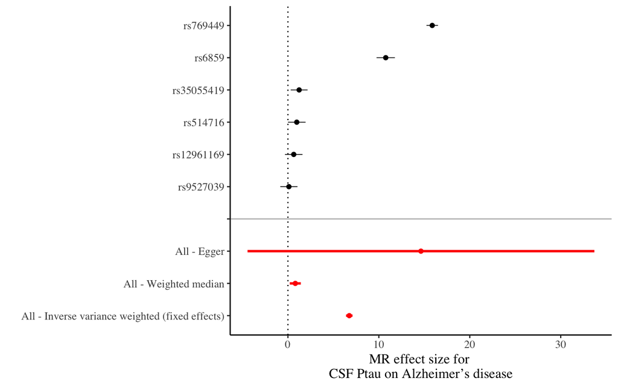

Fig. 2: Forrest plot of Wald ratios and 95% CIs for SNP-specific and overall IVW, Weighted median and Egger associations

**Table 1:** MR estimates for CSF Ptau, on Alzheimer’s disease

|  | SNP | b | se | p |
| --- | --- | --- | --- | --- |
| 1 | rs12961169 | 0.6394884 | 0.4916067 | 1.933225e-01 |
| 2 | rs35055419 | 1.2349570 | 0.4727794 | 8.998234e-03 |
| 3 | rs514716 | 0.9721083 | 0.4963084 | 5.015055e-02 |
| 4 | rs6859 | 10.7568438 | 0.5152979 | 9.036899e-97 |
| 5 | rs769449 | 15.8701135 | 0.3240858 | 0.000000e+00 |
| 6 | rs9527039 | 0.1082322 | 0.4821253 | 8.223762e-01 |
| 7 | All - Inverse variance weighted (fixed effects) | 6.7478343 | 0.1817869 | 1.363067e-301 |
| 8 | All - Weighted median | 0.8123738 | 0.3089467 | 8.551172e-03 |
| 9 | All - MR Egger | 14.6292754 | 9.7303981 | 2.071512e-01 |

Figure 3 shows a funnel plot to detect pleiotropy and Table 2 show the results of Cochrans Q heterogeneity test to assess for the presence of pleiotropy.

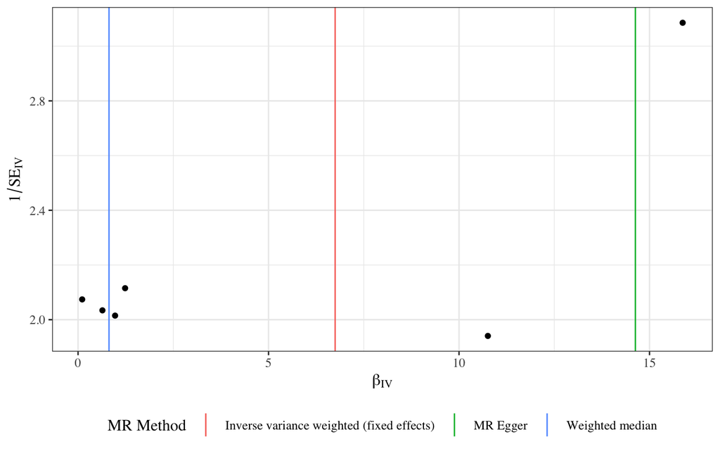

Fig. 3: Funnel plot of the MR causal estimates against their precession

**Table 2:** Heterogenity tests for CSF Ptau on Alzheimer’s disease

| id.exposure | id.outcome | outcome | exposure | method | Q | Q_df | Q_pval |
| --- | --- | --- | --- | --- | --- | --- | --- |
| cN8Th9 | U4vgj3 | load | ptau | MR Egger | 1240.170 | 4 | 3.116082e-267 |
| cN8Th9 | U4vgj3 | load | ptau | Inverse variance weighted | 1468.263 | 5 | 2.221885e-315 |

**Table 3:** Test for directional pleitropy for CSF Ptau on Alzheimer’s disease

| id.exposure | id.outcome | outcome | exposure | egger_intercept | se | pval |
| --- | --- | --- | --- | --- | --- | --- |
| cN8Th9 | U4vgj3 | load | ptau | -0.3935312 | 0.4588116 | 0.4394006 |

### Exposure: Alzheimer’s disease ~ Outcome: CSF Ptau

Figure 4 illustrates the SNP-specific associations with Alzheimer’s disease versus the association in CSF Ptau.

[figure not shown]

Figure 5 and Table 4 shows the SNP-specific effects and overall IVW, weighted median and Egger regression causal estimates of genetically predicted Alzheimer’s disease on CSF Ptau.

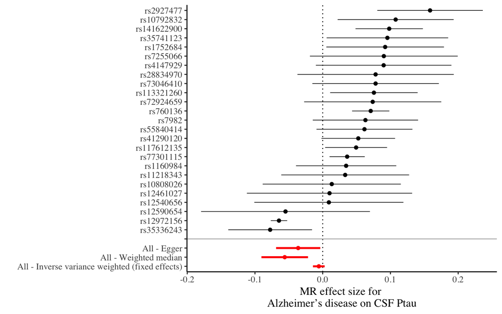

Fig. 5: Forrest plot of Wald ratios and 95% CIs for SNP-specific and overall IVW, Weighted median and Egger associations

**Table 4:** MR estimates for Alzheimer’s disease, on CSF Ptau

|  | SNP | b | se | p |
| --- | --- | --- | --- | --- |
| 1 | rs10792832 | 0.107710100 | 0.043693138 | 1.369562e-02 |
| 2 | rs10808026 | 0.013374013 | 0.052024408 | 7.971233e-01 |
| 3 | rs11218343 | 0.033192436 | 0.048164627 | 4.907317e-01 |
| 4 | rs113321260 | 0.075605282 | 0.032945708 | 2.174203e-02 |
| 5 | rs1160984 | 0.034579164 | 0.037757504 | 3.597601e-01 |
| 6 | rs117612135 | 0.049328817 | 0.023334588 | 3.451710e-02 |
| 7 | rs12461027 | 0.010086605 | 0.062240185 | 8.712591e-01 |
| 8 | rs12540656 | 0.009111789 | 0.056158537 | 8.711081e-01 |
| 9 | rs12590654 | -0.054911917 | 0.063606218 | 3.879668e-01 |
| 10 | rs12972156 | -0.064549522 | 0.006194403 | 1.996468e-25 |

[output cut: 18 more lines]

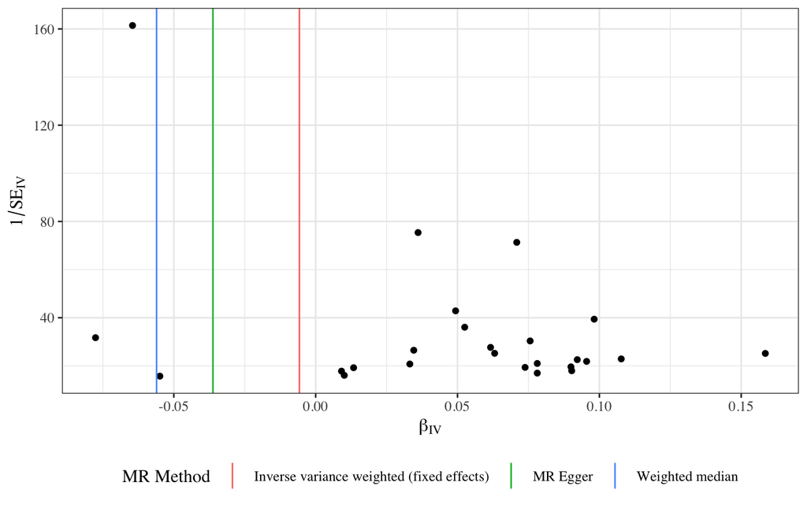

Fig. 6: Funnel plot of the MR causal estimates against their precession

**Table 5:** Heterogenity tests for Alzheimer’s disease and CSF Ptau

| exposure | outcome | method | Q | Q_df | Q_pval |
| --- | --- | --- | --- | --- | --- |
| load | ptau | MR Egger | 171.6411 | 23 | 1.027280e-24 |
| load | ptau | Inverse variance weighted | 224.7142 | 24 | 1.598328e-34 |

**Table 6:** Test for directional pleitropy for Alzheimer’s disease and CSF Ptau

| id.exposure | id.outcome | outcome | exposure | egger_intercept | se | pval |
| --- | --- | --- | --- | --- | --- | --- |
| tfAH9i | TLHERk | ptau | load | 0.01487383 | 0.005577404 | 0.01377658 |

## MR analysis results

| exposure | outcome | method | nsnp | b | se | pval | Signif |
| --- | --- | --- | --- | --- | --- | --- | --- |
| ptau | load | IVW | 6 | 6.747834345 | 0.18178690 | 1.363067e-301 | *** |
| ptau | load | Weighted median | 6 | 0.812373849 | 0.29700143 | 6.233249e-03 | ** |
| ptau | load | MR Egger | 6 | 14.629275375 | 9.73039808 | 2.071512e-01 |  |
| load | ptau | IVW | 25 | -0.005737683 | 0.00442264 | 1.945131e-01 |  |
| load | ptau | Weighted median | 25 | -0.056077579 | 0.01667534 | 7.712671e-04 | *** |
| load | ptau | MR Egger | 25 | -0.036210605 | 0.01662945 | 3.995501e-02 | * |